# HW06

Chongdan Pan

2022/3/10

### Problem 1

```r
library(quadprog)
dat = read.csv("../Stock_Bond.csv", header = TRUE)
prices = cbind(dat$GM_AC, dat$F_AC, dat$CAT_AC, dat$UTX_AC,
dat$MRK_AC, dat$IBM_AC)
n = dim(prices)[1]
returns = 100 * (prices[2:n, ] / prices[1:(n-1), ] - 1)
mean_vect = colMeans(returns)
cov_mat = cov(returns)
sd_vect = sqrt(diag(cov_mat))
Amat = cbind(rep(1, ncol(prices)), mean_vect, diag(1, nrow=ncol(prices)), diag(-1, nrow=ncol(prices)))
weights = matrix(0, nrow = 300, ncol = ncol(prices)) # storage for weights
muP = seq(0.04, max(mean_vect), length = 300)
sdP = muP
for(i in 1:length(muP)){
  bvec = c(1,muP[i], rep(-0.1, ncol(prices)), rep(-0.5, ncol(prices)))
  result = solve.QP(Dmat=2 * cov_mat, dvec = rep(0, ncol(prices)), Amat=Amat, bvec=bvec, meq=2)
  sdP[i] = sqrt(result$value)
  weights[i,] = result$solution
}
plot(sdP, muP, type = "l", xlim = c(0, 2.5), ylim = c(0, 0.1), lty = 3)

mufree = 3 / 365
points(0, mufree, cex=4, pch="*")
sharpe = (muP - mufree) / sdP
ind = (sharpe == max(sharpe)) # tangency
options(digits=3)
weights[ind,]
```

```
## [1] -0.09093 -0.00282  0.33502  0.38350  0.31945  0.05578
```

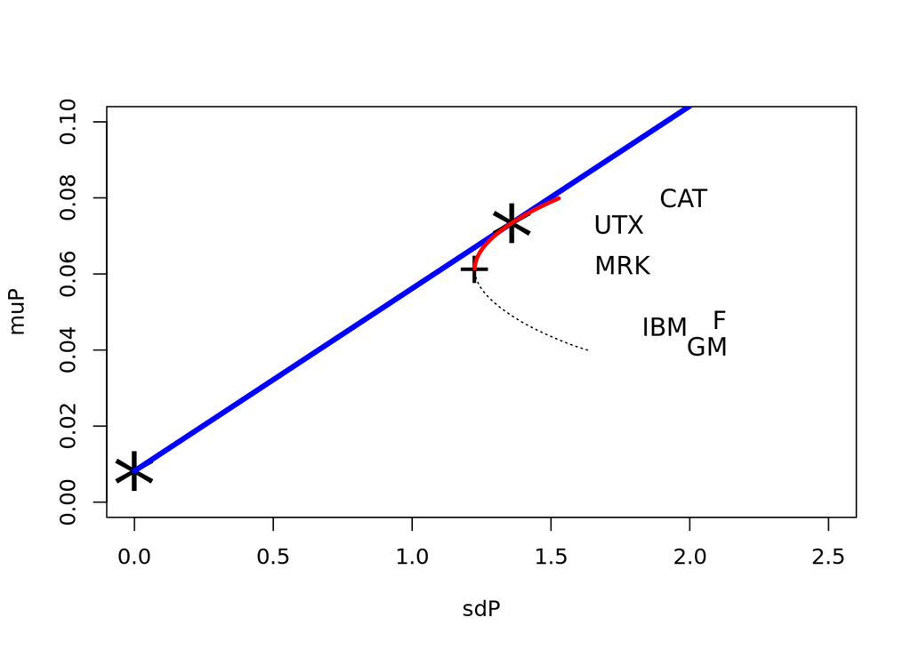

```r
lines(c(0, 2), mufree + c(0, 2) * (muP[ind] - mufree) / sdP[ind], lwd = 4, lty = 1, col = "blue")
points(sdP[ind], muP[ind], cex = 4, pch = "*")
ind2 = (sdP == min(sdP))  # min var
points(sdP[ind2], muP[ind2], cex = 2, pch = "+")
ind3 = (muP > muP[ind2])
lines(sdP[ind3], muP[ind3], type = "l", xlim = c(0, 0.25), ylim = c(0, 0.3), lwd = 3, col = "red")
stock_name = c("GM", "F", "CAT", "UTX", "MRK", "IBM")
for(i in 1:6){
   text(sd_vect[i], mean_vect[i], stock_name[i], cex = 1.15)
}
```

```r
w = (0.07 - mufree) / (muP[ind] - mufree)
w_f = 1 - w
weight = w * weights[ind]
```

Based on the calculation, we have the follow weight

| Asset | Risk Free | GM | F | CAT | UTX | MRK | IBM |
| --- | --- | --- | --- | --- | --- | --- | --- |
| Weight | 0.0516 | -0.0862 | -0.0027 | 0.31773 | 0.3637 | 0.303 | 0.0529 |

Based on the CML, the portfolio needs to satisfy $\mu_R=\mu_f+\frac{\mu_M-\mu_f}{\sigma_M}\sigma_R$

Based on previous calculation, we have $\mu_R=0.07,\mu_f\approx0.0082,\mu_M=0.0734,\sigma_M=1.36,\sigma_R=1.29$, therefore the right side is $0.0082+\frac{0.0734-0.0082}{1.36}1.29=0.07$, hence it equals to $\mu_R$

### Problem 3

$$E[X_n]=E[U]E[\delta_n]+E[\epsilon_n]=0.5\cdot1+0=0.5\\
\sigma_{n,m}=\text{Cov}(U\delta_n,U\delta_m)+\text{Cov}(\epsilon_m, \epsilon_n)\\
\text{Cov}(U\delta_n,U\delta_m)=E[(U\delta_n-E[U\delta_n])\cdot(U\delta_m-E[U\delta_m])]=E[(U\delta_n-\frac{1}{2})\cdot(U\delta_m-\frac{1}{2})]\\
\text{Cov}(U\delta_n,U\delta_m)=\frac{1}{4}+(E[U]^2+\sigma_u)E[\delta_m\delta_n]-\frac{1}{2}(E[U\delta_m]+E[U\delta_n])=-\frac{1}{4}+\frac{1}{3}E[\delta_m\delta_n]$$

Therefore, the time series is weakly stationary

2. Since $\bar X_n=\frac{1}{N}\sum_{n=1}^N U\delta_n+\epsilon_n\rightarrow U\neq E[X_n]$, hence it’s not ergodic